# Kerri Anderson

```
Personal_Loan     0    1   All
Family
All            4520  480  5000
4              1088  134  1222
3               877  133  1010
1              1365  107  1472
2              1190  106  1296
------------------------------------------------------------------------------------------------------------------------
```

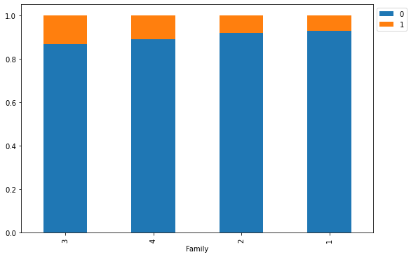

```python
stacked_barplot(loandata, "Family", "Personal_Loan")
```

Family size seems to be an informative predictor

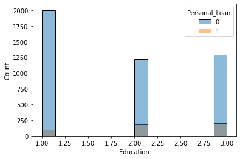

```python
sns.histplot(data=loandata,x="Education",hue="Personal_Loan")
```

```
Personal_Loan     0    1   All
Education
All            4520  480  5000
3              1296  205  1501
2              1221  182  1403
1              2003   93  2096
------------------------------------------------------------------------------------------------------------------------
```

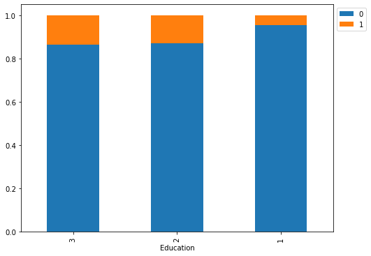

```python
stacked_barplot(loandata, "Education", "Personal_Loan")
```

Higher education, more likely to get a personal loan.

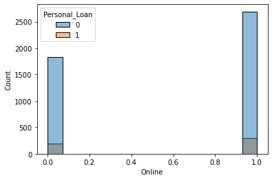

```python
sns.histplot(data=loandata,x="Online",hue="Personal_Loan")
```

```
Personal_Loan     0    1   All
Online
All            4520  480  5000
1              2693  291  2984
0              1827  189  2016
------------------------------------------------------------------------------------------------------------------------
```

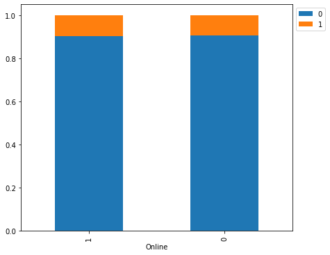

```python
stacked_barplot(loandata, "Online", "Personal_Loan")
```

Using online banking services does not appear to be informative

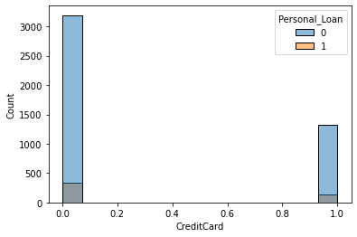

```python
sns.histplot(data=loandata,x="CreditCard",hue="Personal_Loan")
```

```
Personal_Loan     0    1   All
CreditCard
All            4520  480  5000
0              3193  337  3530
1              1327  143  1470
------------------------------------------------------------------------------------------------------------------------
```

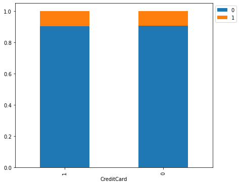

```python
stacked_barplot(loandata, "CreditCard", "Personal_Loan")
```

Having a credit card does not appear informative

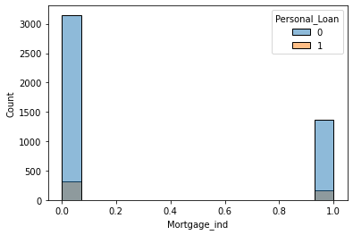

```python
sns.histplot(data=loandata,x="Mortgage_ind",hue="Personal_Loan")
```

```
Personal_Loan     0    1   All
Mortgage_ind
All            4520  480  5000
0              3150  312  3462
1              1370  168  1538
------------------------------------------------------------------------------------------------------------------------
```

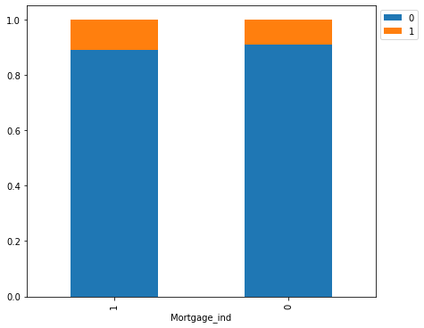

```python
stacked_barplot(loandata, "Mortgage_ind", "Personal_Loan")
```

Mortgage indicator seems to be an informative predictor

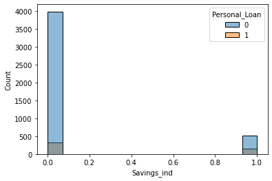

```python
sns.histplot(data=loandata,x="Savings_ind",hue="Personal_Loan")
```

```
Personal_Loan     0    1   All
Savings_ind
All            4520  480  5000
0              3992  331  4323
1               528  149   677
------------------------------------------------------------------------------------------------------------------------
```

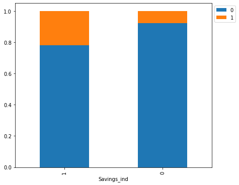

```python
stacked_barplot(loandata, "Savings_ind", "Personal_Loan")
```

Having a savings account, more likely to get a personal loan.

```python
#look at correlations between variables
loandata.corr() # It will show correlation matrix
```

|  | ID | Age | Experience | Income | ZIPCode | Family | CCAvg | Education | Mortgage | Personal_Loan | Securities_Account | CD_Account | Online | CreditCard | Mortgage_ind | Monthly_Income | Monthly_Mortgage | DI_Ratio | Savings_sum | Savings_ind |
| --- | --- | --- | --- | --- | --- | --- | --- | --- | --- | --- | --- | --- | --- | --- | --- | --- | --- | --- | --- | --- |
| ID | 1.000000 | -0.008473 | -0.008265 | -0.017695 | 0.002240 | -0.016797 | -0.024675 | 0.021463 | -0.013920 | -0.024801 | -0.016972 | -0.006909 | -0.002528 | 0.017028 | -0.019057 | -0.017695 | -0.013920 | -0.009735 | -0.015423 | -0.018211 |
| Age | -0.008473 | 1.000000 | 0.994198 | -0.055269 | -0.030530 | -0.046418 | -0.052012 | 0.041334 | -0.012539 | -0.007726 | -0.000436 | 0.008043 | 0.013702 | 0.007681 | -0.009545 | -0.055269 | -0.012539 | -0.016056 | 0.004022 | -0.000107 |
| Experience | -0.008265 | 0.994198 | 1.000000 | -0.046729 | -0.030649 | -0.052213 | -0.049912 | 0.013536 | -0.010840 | -0.007858 | -0.001111 | 0.010046 | 0.013975 | 0.008910 | -0.008787 | -0.046729 | -0.010840 | -0.021983 | 0.004633 | 0.000257 |
| Income | -0.017695 | -0.055269 | -0.046729 | 1.000000 | -0.030709 | -0.157501 | 0.645984 | -0.187524 | 0.206806 | 0.502462 | -0.002616 | 0.169738 | 0.014206 | -0.002385 | -0.003688 | 1.000000 | 0.206806 | -0.178404 | 0.089428 | 0.085617 |
| ZIPCode | 0.002240 | -0.030530 | -0.030649 | -0.030709 | 1.000000 | 0.027512 | -0.012188 | -0.008266 | 0.003614 | -0.002974 | 0.002422 | 0.021671 | 0.028317 | 0.024033 | 0.006470 | -0.030709 | 0.003614 | 0.011242 | 0.013319 | 0.003082 |
| Family | -0.016797 | -0.046418 | -0.052213 | -0.157501 | 0.027512 | 1.000000 | -0.109275 | 0.064929 | -0.020445 | 0.061367 | 0.019994 | 0.014110 | 0.010354 | 0.011588 | 0.005037 | -0.157501 | -0.020445 | 0.017905 | 0.021378 | 0.030887 |
| CCAvg | -0.024675 | -0.052012 | -0.049912 | 0.645984 | -0.012188 | -0.109275 | 1.000000 | -0.136124 | 0.109905 | 0.366889 | 0.015086 | 0.136534 | -0.003611 | -0.006689 | -0.011398 | 0.645984 | 0.109905 | 0.459217 | 0.083794 | 0.082581 |
| Education | 0.021463 | 0.041334 | 0.013536 | -0.187524 | -0.008266 | 0.064929 | -0.136124 | 1.000000 | -0.033327 | 0.136722 | -0.010812 | 0.013934 | -0.015004 | -0.011014 | -0.000505 | -0.187524 | -0.033327 | 0.013214 | 0.000030 | 0.005264 |
| Mortgage | -0.013920 | -0.012539 | -0.010840 | 0.206806 | 0.003614 | -0.020445 | 0.109905 | -0.033327 | 1.000000 | 0.142095 | -0.005411 | 0.089311 | -0.005995 | -0.007231 | 0.833466 | 0.206806 | 1.000000 | 0.138432 | 0.044271 | 0.041292 |
| Personal_Loan | -0.024801 | -0.007726 | -0.007858 | 0.502462 | -0.002974 | 0.061367 | 0.366889 | 0.136722 | 0.142095 | 1.000000 | 0.021954 | 0.316355 | 0.006278 | 0.002802 | 0.029940 | 0.502462 | 0.142095 | -0.013021 | 0.185185 | 0.166692 |
| Securities_Account | -0.016972 | -0.000436 | -0.001111 | -0.002616 | 0.002422 | 0.019994 | 0.015086 | -0.010812 | -0.005411 | 0.021954 | 1.000000 | 0.317034 | 0.012627 | -0.015028 | -0.002221 | -0.002616 | -0.005411 | 0.012333 | 0.860312 | 0.862763 |
| CD_Account | -0.006909 | 0.008043 | 0.010046 | 0.169738 | 0.021671 | 0.014110 | 0.136534 | 0.013934 | 0.089311 | 0.316355 | 0.317034 | 1.000000 | 0.175880 | 0.278644 | 0.040212 | 0.169738 | 0.089311 | 0.008192 | 0.756219 | 0.640686 |
| Online | -0.002528 | 0.013702 | 0.013975 | 0.014206 | 0.028317 | 0.010354 | -0.003611 | -0.015004 | -0.005995 | 0.006278 | 0.012627 | 0.175880 | 1.000000 | 0.004210 | -0.004310 | 0.014206 | -0.005995 | -0.027380 | 0.103246 | 0.080990 |
| CreditCard | 0.017028 | 0.007681 | 0.008910 | -0.002385 | 0.024033 | 0.011588 | -0.006689 | -0.011014 | -0.007231 | 0.002802 | -0.015028 | 0.278644 | 0.004210 | 1.000000 | -0.004920 | -0.002385 | -0.007231 | -0.005080 | 0.139402 | 0.110292 |
| Mortgage_ind | -0.019057 | -0.009545 | -0.008787 | -0.003688 | 0.006470 | 0.005037 | -0.011398 | -0.000505 | 0.833466 | 0.029940 | -0.002221 | 0.040212 | -0.004310 | -0.004920 | 1.000000 | -0.003688 | 0.833466 | 0.220326 | 0.020081 | 0.022488 |
| Monthly_Income | -0.017695 | -0.055269 | -0.046729 | 1.000000 | -0.030709 | -0.157501 | 0.645984 | -0.187524 | 0.206806 | 0.502462 | -0.002616 | 0.169738 | 0.014206 | -0.002385 | -0.003688 | 1.000000 | 0.206806 | -0.178404 | 0.089428 | 0.085617 |
| Monthly_Mortgage | -0.013920 | -0.012539 | -0.010840 | 0.206806 | 0.003614 | -0.020445 | 0.109905 | -0.033327 | 1.000000 | 0.142095 | -0.005411 | 0.089311 | -0.005995 | -0.007231 | 0.833466 | 0.206806 | 1.000000 | 0.138432 | 0.044271 | 0.041292 |
| DI_Ratio | -0.009735 | -0.016056 | -0.021983 | -0.178404 | 0.011242 | 0.017905 | 0.459217 | 0.013214 | 0.138432 | -0.013021 | 0.012333 | 0.008192 | -0.027380 | -0.005080 | 0.220326 | -0.178404 | 0.138432 | 1.000000 | 0.012912 | 0.018422 |
| Savings_sum | -0.015423 | 0.004022 | 0.004633 | 0.089428 | 0.013319 | 0.021378 | 0.083794 | 0.000030 | 0.044271 | 0.185185 | 0.860312 | 0.756219 | 0.103246 | 0.139402 | 0.020081 | 0.089428 | 0.044271 | 0.012912 | 1.000000 | 0.939592 |
| Savings_ind | -0.018211 | -0.000107 | 0.000257 | 0.085617 | 0.003082 | 0.030887 | 0.082581 | 0.005264 | 0.041292 | 0.166692 | 0.862763 | 0.640686 | 0.080990 | 0.110292 | 0.022488 | 0.085617 | 0.041292 | 0.018422 | 0.939592 | 1.000000 |

The correlation matrix is very telling. The most highly correlated variables with Personal Loan include

Income (0.50) CCAvg (0.37) CD_Account (0.32)

For the variables which we created: mortgage is more highly correlated with the target than mortgage indicator, the CD_account indicator was more highly correlated than the combination indicator of CD_account and securities account, and debt to income ratio appears to be slightly negatively correlated with the outcome and may not add value to our model.

```python
def plot_corr(df, size=30):
    corr = df.corr()
    fig, ax = plt.subplots(figsize=(size, size))
    ax.matshow(corr)
    plt.xticks(range(len(corr.columns)), corr.columns)
    plt.yticks(range(len(corr.columns)), corr.columns)
    for (i, j), z in np.ndenumerate(corr):
        ax.text(j, i, '{:0.1f}'.format(z), ha='center', va='center')
```

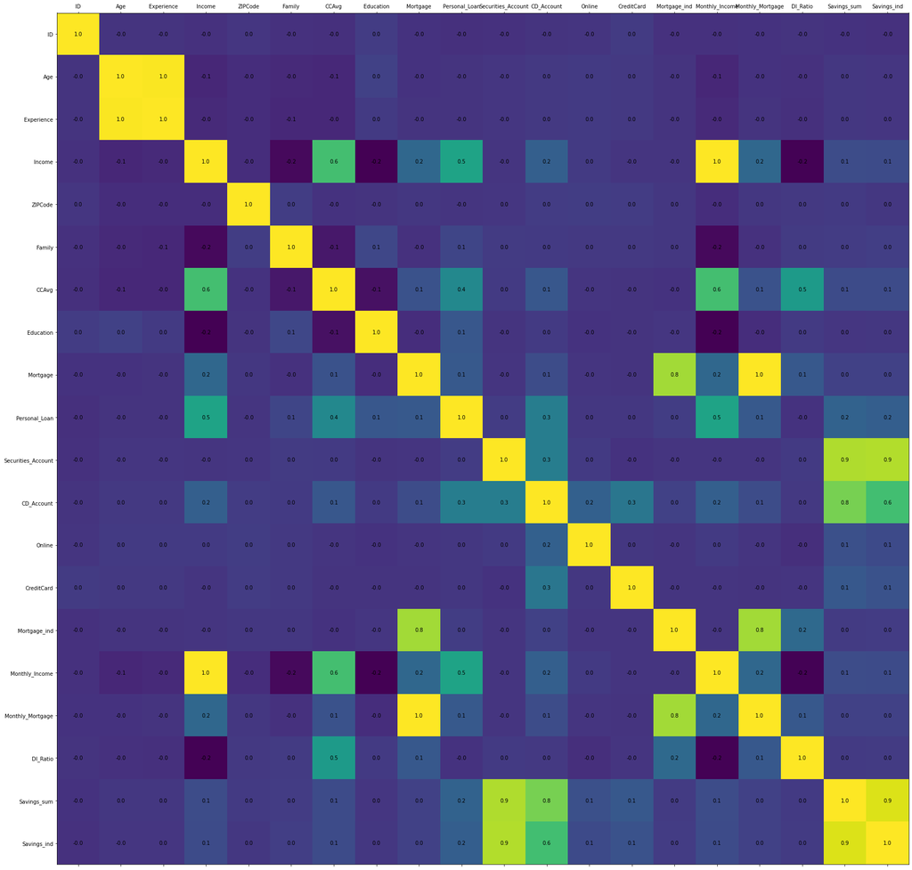

```python
plot_corr(loandata)
```

Other observations from the correlation matrix:

Age and experience are highly correlated, so only include one in model

```python
#just for fun
#sns.pairplot(loandata,diag_kind='kde')
```

## Prepare to build model - split data

```python
#Evaluate distribution of positives (took personal loan) and negatives (no personal loan)
#will need to compare to the distribution in test and train datasets
n_true = len(loandata.loc[loandata['Personal_Loan'] == True])
n_false = len(loandata.loc[loandata['Personal_Loan'] == False])
print("Number of positive personal loans: {0} ({1:2.2f}%)".format(n_true, (n_true / (n_true + n_false)) * 100 ))
print("Number of negative personal loans: {0} ({1:2.2f}%)".format(n_false, (n_false / (n_true + n_false)) * 100))
```

```
Number of positive personal loans: 480 (9.60%)
Number of negative personal loans: 4520 (90.40%)
```

```python
#get list of variables in dataframe
#only keep variables needed for analysis
list(loandata)
```

```
['ID',
 'Age',
 'Experience',
 'Income',
 'ZIPCode',
 'Family',
 'CCAvg',
 'Education',
 'Mortgage',
 'Personal_Loan',
 'Securities_Account',
 'CD_Account',
 'Online',
 'CreditCard',
 'Mortgage_ind',
 'Monthly_Income',
 'Monthly_Mortgage',
 'DI_Ratio',
 'Savings_sum',
 'Savings_ind']
```

I am going to create three datasets to train/test the data. The first includes the original variables (excluding ID and zip code), the second includes variables which I created in addition to the original ones, the third has a reduced number of variables, based on observations in the bivariate analysis (remove one of pair of highly correlated variables such as age and experience).

Each of these sets of variables can be used to compare model performance and the best model can be chosen. We want to find the simplest model that provides the most predictive value.

The goal is to properly identify individuals that will purchase a loan. The bank wants to set up a marketing approach to target individuals to buy a loan. It is alright to have more false positives, to a certain degree, but we want to reduce false negatives. It is a small price to market to too many people, but there is opportunity lost cost if we miss someone with our marketing that could have purchased a personal loan. Want to ensure a strong recall with reasonable precision (balance between lost opportunity cost, and wasted marketing dollars on those who will not purchase a loan even with good marketing)

```python
from sklearn.model_selection import train_test_split

#use the original data given to use for the _ORIG dataset
#can compare the model performance to reduced number of variables
X_orig = loandata.drop([
'ID',
 #'Age',
 #'Experience',
 #'Income',
 'ZIPCode',
 #'Family',
 #'CCAvg',
 #'Education',
 #'Mortgage',
 'Personal_Loan',
 #'Securities_Account',
 #'CD_Account',
 #'Online',
 #'CreditCard',
 'Mortgage_ind',
 'Monthly_Income',
 'Monthly_Mortgage',
 'DI_Ratio',
 'Savings_sum',
 'Savings_ind'],axis=1)     # Predictor feature columns (8 X m)
Y_orig = loandata['Personal_Loan']   # Predicted class (1=True, 0=False) (1 X m)

x_train_orig, x_test_orig, y_train_orig, y_test_orig = train_test_split(X_orig, Y_orig, test_size=0.3, random_state=1)
# 1 is just any random seed number

x_train_orig.head()
```

|  | Age | Experience | Income | Family | CCAvg | Education | Mortgage | Securities_Account | CD_Account | Online | CreditCard |
| --- | --- | --- | --- | --- | --- | --- | --- | --- | --- | --- | --- |
| 1334 | 47 | 22 | 35 | 2 | 1.3 | 1 | 0 | 0 | 0 | 1 | 0 |
| 4768 | 38 | 14 | 39 | 1 | 2.0 | 2 | 0 | 0 | 0 | 1 | 0 |
| 65 | 59 | 35 | 131 | 1 | 3.8 | 1 | 0 | 0 | 0 | 1 | 1 |
| 177 | 29 | 3 | 65 | 4 | 1.8 | 2 | 244 | 0 | 0 | 0 | 0 |
| 4489 | 39 | 13 | 21 | 3 | 0.2 | 2 | 0 | 0 | 0 | 1 | 0 |

```python
#use additional variables and see if this enhances model performance
X_add = loandata.drop([
'ID',
 #'Age',
 #'Experience',
 #'Income',
 'ZIPCode',
 #'Family',
 #'CCAvg',
 #'Education',
 #'Mortgage',
 'Personal_Loan',
 #'Securities_Account',
 #'CD_Account',
 #'Online',
 #'CreditCard',
 #'Mortgage_ind',
 'Monthly_Income',
 'Monthly_Mortgage',
 #'DI_Ratio',
 #'Savings_sum',
 'Savings_ind'],axis=1)     # Predictor feature columns
Y_add = loandata['Personal_Loan']   # Predicted class (1=True, 0=False)

x_train_add, x_test_add, y_train_add, y_test_add = train_test_split(X_add, Y_add, test_size=0.3, random_state=1)
# 1 is just any random seed number

x_train_add.head()
```

|  | Age | Experience | Income | Family | CCAvg | Education | Mortgage | Securities_Account | CD_Account | Online | CreditCard | Mortgage_ind | DI_Ratio | Savings_sum |
| --- | --- | --- | --- | --- | --- | --- | --- | --- | --- | --- | --- | --- | --- | --- |
| 1334 | 47 | 22 | 35 | 2 | 1.3 | 1 | 0 | 0 | 0 | 1 | 0 | 0 | 0.445714 | 0 |
| 4768 | 38 | 14 | 39 | 1 | 2.0 | 2 | 0 | 0 | 0 | 1 | 0 | 0 | 0.615385 | 0 |
| 65 | 59 | 35 | 131 | 1 | 3.8 | 1 | 0 | 0 | 0 | 1 | 1 | 0 | 0.348092 | 0 |
| 177 | 29 | 3 | 65 | 4 | 1.8 | 2 | 244 | 0 | 0 | 0 | 0 | 1 | 0.457436 | 0 |
| 4489 | 39 | 13 | 21 | 3 | 0.2 | 2 | 0 | 0 | 0 | 1 | 0 | 0 | 0.114286 | 0 |

```python
#create a reduced model (fewer variables)
#remove experience, use mortgage indicator rather than mortgage
X_reduced =  loandata.drop([
'ID',
 #'Age',
 'Experience',
 #'Income',
 'ZIPCode',
 #'Family',
 'CCAvg',
 #'Education',
 'Mortgage',
 'Personal_Loan',
 'Securities_Account',
 #'CD_Account',
 #'Online',
 #'CreditCard',
 #'Mortgage_ind',
 'Monthly_Income',
 'Monthly_Mortgage',
 #'DI_Ratio',
 'Savings_sum',
 'Savings_ind'],axis=1)      # Predictor feature columns (8 X m)
Y_reduced = loandata['Personal_Loan']   # Predicted class (1=True, 0=False) (1 X m)

x_train_reduced, x_test_reduced, y_train_reduced, y_test_reduced = train_test_split(X_reduced, Y_reduced, test_size=0.3, random_state=1)
# 1 is just any random seed number

x_train_reduced.head()
```

|  | Age | Income | Family | Education | CD_Account | Online | CreditCard | Mortgage_ind | DI_Ratio |
| --- | --- | --- | --- | --- | --- | --- | --- | --- | --- |
| 1334 | 47 | 35 | 2 | 1 | 0 | 1 | 0 | 0 | 0.445714 |
| 4768 | 38 | 39 | 1 | 2 | 0 | 1 | 0 | 0 | 0.615385 |
| 65 | 59 | 131 | 1 | 1 | 0 | 1 | 1 | 0 | 0.348092 |
| 177 | 29 | 65 | 4 | 2 | 0 | 0 | 0 | 1 | 0.457436 |
| 4489 | 39 | 21 | 3 | 2 | 0 | 1 | 0 | 0 | 0.114286 |

```python
#check data split
print("{0:0.2f}% data is in training set _orig".format((len(x_train_orig)/len(loandata.index)) * 100))
print("{0:0.2f}% data is in test set _orig".format((len(x_test_orig)/len(loandata.index)) * 100))
print("{0:0.2f}% data is in training set _add".format((len(x_train_add)/len(loandata.index)) * 100))
print("{0:0.2f}% data is in test set _add".format((len(x_test_add)/len(loandata.index)) * 100))
print("{0:0.2f}% data is in training set _reduced".format((len(x_train_reduced)/len(loandata.index)) * 100))
print("{0:0.2f}% data is in test set _reduced".format((len(x_test_reduced)/len(loandata.index)) * 100))
```

```
70.00% data is in training set _orig
30.00% data is in test set _orig
70.00% data is in training set _add
30.00% data is in test set _add
70.00% data is in training set _reduced
30.00% data is in test set _reduced
```

```python
print("Original  True Values    : {0} ({1:0.2f}%)".format(len(loandata.loc[loandata['Personal_Loan'] == 1]), (len(loandata.loc[loandata['Personal_Loan'] == 1])/len(loandata.index)) * 100))
print("Original  False Values   : {0} ({1:0.2f}%)".format(len(loandata.loc[loandata['Personal_Loan'] == 0]), (len(loandata.loc[loandata['Personal_Loan'] == 0])/len(loandata.index)) * 100))
print("")
print("Training  True Values    : {0} ({1:0.2f}%)".format(len(y_train_orig[y_train_orig[:] == 1]), (len(y_train_orig[y_train_orig[:] == 1])/len(y_train_orig)) * 100))
print("Training  False Values   : {0} ({1:0.2f}%)".format(len(y_train_orig[y_train_orig[:] == 0]), (len(y_train_orig[y_train_orig[:] == 0])/len(y_train_orig)) * 100))
print("")
print("Test  True Values        : {0} ({1:0.2f}%)".format(len(y_test_orig[y_test_orig[:] == 1]), (len(y_test_orig[y_test_orig[:] == 1])/len(y_test_orig)) * 100))
print("Test  False Values       : {0} ({1:0.2f}%)".format(len(y_test_orig[y_test_orig[:] == 0]), (len(y_test_orig[y_test_orig[:] == 0])/len(y_test_orig)) * 100))
print("")
```

```
Original  True Values    : 480 (9.60%)
Original  False Values   : 4520 (90.40%)

Training  True Values    : 331 (9.46%)
Training  False Values   : 3169 (90.54%)

Test  True Values        : 149 (9.93%)
Test  False Values       : 1351 (90.07%)
```

```python
# defining a function to compute different metrics to check performance of a classification model built using sklearn

def model_performance_classification_sklearn_with_threshold(model, predictors, target, threshold=0.5):
    """
    Function to compute different metrics, based on the threshold specified, to check classification model performance

    model: classifier
    predictors: independent variables
    target: dependent variable
    threshold: threshold for classifying the observation as class 1
    """

    # predicting using the independent variables
    pred_prob = model.predict_proba(predictors)[:, 1]
    pred_thres = pred_prob > threshold
    pred = np.round(pred_thres)

    acc = accuracy_score(target, pred)  # to compute Accuracy
    recall = recall_score(target, pred)  # to compute Recall
    precision = precision_score(target, pred)  # to compute Precision
    f1 = f1_score(target, pred)  # to compute F1-score

    # creating a dataframe of metrics
    df_perf = pd.DataFrame(
        {
            "Accuracy": acc,
            "Recall": recall,
            "Precision": precision,
            "F1": f1,
        },
        index=[0],
    )

    return df_perf
```

```python
# defining a function to plot the confusion_matrix of a classification model built using sklearn
def confusion_matrix_sklearn_with_threshold(model, predictors, target, threshold=0.5):
    """
    To plot the confusion_matrix, based on the threshold specified, with percentages

    model: classifier
    predictors: independent variables
    target: dependent variable
    threshold: threshold for classifying the observation as class 1
    """
    pred_prob = model.predict_proba(predictors)[:, 1]
    pred_thres = pred_prob > threshold
    y_pred = np.round(pred_thres)

    cm = confusion_matrix(target, y_pred)
    labels = np.asarray(
        [
            ["{0:0.0f}".format(item) + "\n{0:.2%}".format(item / cm.flatten().sum())]
            for item in cm.flatten()
        ]
    ).reshape(2, 2)

    plt.figure(figsize=(6, 4))
    sns.heatmap(cm, annot=labels, fmt="")
    plt.ylabel("True label")
    plt.xlabel("Predicted label")
```

# Logistic Regression

## Original variables in model

Perform logistic regression with original dataset and evaluate

```python
# There are different solvers available in Sklearn logistic regression
# The newton-cg solver is faster for high-dimensional data

lg = LogisticRegression(solver="newton-cg", random_state=1)
model = lg.fit(x_train_orig, y_train_orig)
```

```python
# let us check the coefficients and intercept of the model

coef_df_orig = pd.DataFrame(
    np.append(lg.coef_, lg.intercept_),
    index=x_train_orig.columns.tolist() + ["Intercept"],
    columns=["Coefficients"],
)
coef_df_orig.T
```

|  | Age | Experience | Income | Family | CCAvg | Education | Mortgage | Securities_Account | CD_Account | Online | CreditCard | Intercept |
| --- | --- | --- | --- | --- | --- | --- | --- | --- | --- | --- | --- | --- |
| Coefficients | -0.029215 | 0.03486 | 0.05241 | 0.712831 | 0.168176 | 1.669413 | 0.000784 | -0.840593 | 3.258272 | -0.531716 | -0.949577 | -12.658865 |

```python
# converting coefficients to odds
odds = np.exp(lg.coef_[0])

# finding the percentage change
perc_change_odds = (np.exp(lg.coef_[0]) - 1) * 100

# removing limit from number of columns to display
pd.set_option("display.max_columns", None)

# adding the odds to a dataframe
pd.DataFrame({"Odds": odds, "Change_odd%": perc_change_odds}, index=x_train_orig.columns).T
```

|  | Age | Experience | Income | Family | CCAvg | Education | Mortgage | Securities_Account | CD_Account | Online | CreditCard |
| --- | --- | --- | --- | --- | --- | --- | --- | --- | --- | --- | --- |
| Odds | 0.971207 | 1.035475 | 1.053808 | 2.039757 | 1.183145 | 5.309050 | 1.000784 | 0.431455 | 26.004563 | 0.587596 | 0.386905 |
| Change_odd% | -2.879264 | 3.547496 | 5.380813 | 103.975726 | 18.314458 | 430.905035 | 0.078397 | -56.854548 | 2500.456276 | -41.240443 | -61.309531 |

The variables with a positive impact on taking out a personal loan (indicate that a customer is more likely to take out a personal loan) are increased family size, increased level of education, having a CD account.

Variables which indicate you are less likely to take out a personal loan are having a securities account, using online features, and using a credit card with another bank.

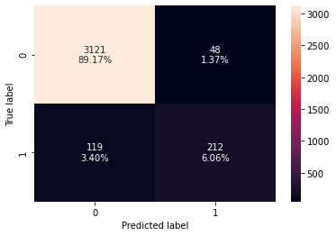

```python
# creating confusion matrix
confusion_matrix_sklearn_with_threshold(lg, x_train_orig, y_train_orig)
```

```python
log_reg_model_train_perf = model_performance_classification_sklearn_with_threshold(
    lg, x_train_orig, y_train_orig
)

print("Training performance:")
log_reg_model_train_perf
```

```
Training performance:
```

|  | Accuracy | Recall | Precision | F1 |
| --- | --- | --- | --- | --- |
| 0 | 0.952286 | 0.640483 | 0.815385 | 0.717428 |

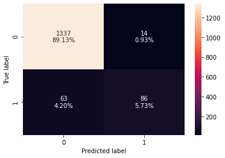

```python
# creating confusion matrix
confusion_matrix_sklearn_with_threshold(lg, x_test_orig, y_test_orig)
```

```python
log_reg_model_test_perf = model_performance_classification_sklearn_with_threshold(
    lg, x_test_orig, y_test_orig
)

print("Test set performance:")
log_reg_model_test_perf
```

```
Test set performance:
```

|  | Accuracy | Recall | Precision | F1 |
| --- | --- | --- | --- | --- |
| 0 | 0.948667 | 0.577181 | 0.86 | 0.690763 |

Let's try to improve the model by comparing the performance measures for the model with additional variables and the model with reduced variables

# Additional variables in model

Look at how the model performs when we add additional variables. Compare this model performance to the original model.

```python
# There are different solvers available in Sklearn logistic regression
# The newton-cg solver is faster for high-dimensional data

#lg = LogisticRegression(solver="newton-cg", random_state=1)
model_add = lg.fit(x_train_add, y_train_add)
```

```python
# let us check the coefficients and intercept of the model

coef_df_add = pd.DataFrame(
    np.append(lg.coef_, lg.intercept_),
    index=x_train_add.columns.tolist() + ["Intercept"],
    columns=["Coefficients"],
)
coef_df_add.T
```

|  | Age | Experience | Income | Family | CCAvg | Education | Mortgage | Securities_Account | CD_Account | Online | CreditCard | Mortgage_ind | DI_Ratio | Savings_sum | Intercept |
| --- | --- | --- | --- | --- | --- | --- | --- | --- | --- | --- | --- | --- | --- | --- | --- |
| Coefficients | -0.044899 | 0.05047 | 0.056615 | 0.717961 | 0.035735 | 1.685175 | 0.000562 | -1.623466 | 2.458897 | -0.540783 | -0.966455 | -0.067889 | 1.526144 | 0.835431 | -12.880886 |

```python
# converting coefficients to odds
odds = np.exp(lg.coef_[0])

# finding the percentage change
perc_change_odds = (np.exp(lg.coef_[0]) - 1) * 100

# removing limit from number of columns to display
pd.set_option("display.max_columns", None)

# adding the odds to a dataframe
pd.DataFrame({"Odds": odds, "Change_odd%": perc_change_odds}, index=x_train_add.columns).T
```

|  | Age | Experience | Income | Family | CCAvg | Education | Mortgage | Securities_Account | CD_Account | Online | CreditCard | Mortgage_ind | DI_Ratio | Savings_sum |
| --- | --- | --- | --- | --- | --- | --- | --- | --- | --- | --- | --- | --- | --- | --- |
| Odds | 0.956094 | 1.051766 | 1.058249 | 2.050249 | 1.036381 | 5.393395 | 1.000562 | 0.197214 | 11.691906 | 0.582292 | 0.380429 | 0.934364 | 4.600405 | 2.305808 |
| Change_odd% | -4.390591 | 5.176554 | 5.824853 | 105.024871 | 3.638067 | 439.339550 | 0.056179 | -80.278596 | 1069.190561 | -41.770782 | -61.957066 | -6.563558 | 360.040542 | 130.580789 |

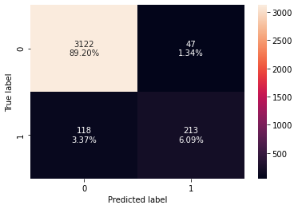

```python
# creating confusion matrix
confusion_matrix_sklearn_with_threshold(lg, x_train_add, y_train_add)
```

```python
log_reg_model_train_perf_add = model_performance_classification_sklearn_with_threshold(
    lg, x_train_add, y_train_add
)

print("Training performance:")
log_reg_model_train_perf_add
```

```
Training performance:
```

|  | Accuracy | Recall | Precision | F1 |
| --- | --- | --- | --- | --- |
| 0 | 0.952857 | 0.643505 | 0.819231 | 0.720812 |

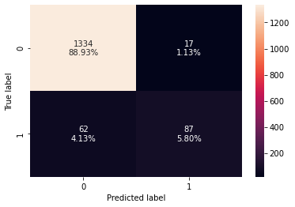

```python
# creating confusion matrix for test
confusion_matrix_sklearn_with_threshold(lg, x_test_add, y_test_add)
```

```python
# performance on test dataset
log_reg_model_test_perf_add = model_performance_classification_sklearn_with_threshold(
    lg, x_test_add, y_test_add
)

print("Test set performance:")
log_reg_model_test_perf_add
```

```
Test set performance:
```

|  | Accuracy | Recall | Precision | F1 |
| --- | --- | --- | --- | --- |
| 0 | 0.947333 | 0.583893 | 0.836538 | 0.687747 |

Additional variables did not seem to enhance the performance of the model. The DIRatio did seem to add some predicitive value. Let's try the simpler model.

# Reduced model variables

Test out the performance of the model with a reduced number of predictor variables

```python
# There are different solvers available in Sklearn logistic regression
# The newton-cg solver is faster for high-dimensional data

#lg = LogisticRegression(solver="newton-cg", random_state=1)
model_reduced = lg.fit(x_train_reduced, y_train_reduced)
```

```python
# let us check the coefficients and intercept of the model

coef_df_reduced = pd.DataFrame(
    np.append(lg.coef_, lg.intercept_),
    index=x_train_reduced.columns.tolist() + ["Intercept"],
    columns=["Coefficients"],
)
coef_df_reduced.T
```

|  | Age | Income | Family | Education | CD_Account | Online | CreditCard | Mortgage_ind | DI_Ratio | Intercept |
| --- | --- | --- | --- | --- | --- | --- | --- | --- | --- | --- |
| Coefficients | 0.005227 | 0.058301 | 0.723855 | 1.669246 | 2.846592 | -0.496373 | -0.871916 | 0.032556 | 1.758965 | -14.360203 |

```python
# converting coefficients to odds
odds = np.exp(lg.coef_[0])

# finding the percentage change
perc_change_odds = (np.exp(lg.coef_[0]) - 1) * 100

# removing limit from number of columns to display
pd.set_option("display.max_columns", None)

# adding the odds to a dataframe
pd.DataFrame({"Odds": odds, "Change_odd%": perc_change_odds}, index=x_train_reduced.columns).T
```

|  | Age | Income | Family | Education | CD_Account | Online | CreditCard | Mortgage_ind | DI_Ratio |
| --- | --- | --- | --- | --- | --- | --- | --- | --- | --- |
| Odds | 1.005241 | 1.060034 | 2.062368 | 5.308165 | 17.228967 | 0.608735 | 0.418150 | 1.033092 | 5.806427 |
| Change_odd% | 0.524106 | 6.003428 | 106.236796 | 430.816536 | 1622.896653 | -39.126544 | -58.185029 | 3.309151 | 480.642680 |

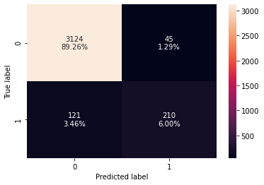

```python
# creating confusion matrix
confusion_matrix_sklearn_with_threshold(lg, x_train_reduced, y_train_reduced)
```

```python
log_reg_model_train_perf_reduced = model_performance_classification_sklearn_with_threshold(
    lg, x_train_reduced, y_train_reduced
)

print("Training performance:")
log_reg_model_train_perf_reduced
```

```
Training performance:
```

|  | Accuracy | Recall | Precision | F1 |
| --- | --- | --- | --- | --- |
| 0 | 0.952571 | 0.634441 | 0.823529 | 0.716724 |

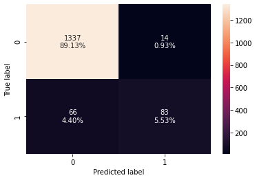

```python
# creating confusion matrix for test
confusion_matrix_sklearn_with_threshold(lg, x_test_reduced, y_test_reduced)
```

```python
# performance on test dataset
log_reg_model_test_perf_reduced = model_performance_classification_sklearn_with_threshold(
    lg, x_test_reduced, y_test_reduced
)

print("Test set performance:")
log_reg_model_test_perf_reduced
```

```
Test set performance:
```

|  | Accuracy | Recall | Precision | F1 |
| --- | --- | --- | --- | --- |
| 0 | 0.946667 | 0.557047 | 0.85567 | 0.674797 |

The model performance was best (highest recall in test dataset) with the additional variables, however, the value was very close to that of the original model. Given this additional complexity, with little gain in model performance, the original variables should remain as our chosen predictors. We will move forward with the original set of variables to build and evaluate a decision tree model.

Higher debt:income ratio indicates more likely to take out a personal loan, and did provide some additional information to the model, but this number also represents that a personal taking out the loan is more likely to default if they aren't able to pay back. We won't include this in the marketing model. The purpose of this model is to market effectively so that people purchase a personal loan. The debt to income ratio should be considered in the underwiting model to determine if the bank will take on the risk. Debt to income should not be considered in this marketing model.

In the original model we see that those with more education, larger family size, and a CD account are more likely to take out a personal loan. We should definitely target this group of customers. We also see that using online services reduces taking out a loan so we might want to target those that come into our banking locations by having printed material in the banks that target these customers. For online customers, we might need to find a unique approach. Customers with CD accounts should be easy to recognize in our system. Education and family size may be in our system (because we have data) or we may need to purchase this data from a third party or vendor. This cost should be considered in the investment cost of the marketing strategy.

## Decision Tree model

```python
#build the decision tree
dTree = DecisionTreeClassifier(criterion = 'gini', random_state=1)
dTree.fit(x_train_orig, y_train_orig)
```

```
DecisionTreeClassifier(random_state=1)
```

```python
#score the decision tree
print("Accuracy on training set : ",dTree.score(x_train_orig, y_train_orig))
print("Accuracy on test set : ",dTree.score(x_test_orig, y_test_orig))
```

```
Accuracy on training set :  1.0
Accuracy on test set :  0.98
```

```python
## Function to create confusion matrix
def make_confusion_matrix(model,y_actual,labels=[1, 0]):
    '''
    model : classifier to predict values of X
    y_actual : ground truth

    '''
    y_predict = model.predict(x_test_orig)
    cm=metrics.confusion_matrix( y_actual, y_predict, labels=[0, 1])
    df_cm = pd.DataFrame(cm, index = [i for i in ["Actual - No","Actual - Yes"]],
                  columns = [i for i in ['Predicted - No','Predicted - Yes']])
    group_counts = ["{0:0.0f}".format(value) for value in
                cm.flatten()]
    group_percentages = ["{0:.2%}".format(value) for value in
                         cm.flatten()/np.sum(cm)]
    labels = [f"{v1}\n{v2}" for v1, v2 in
              zip(group_counts,group_percentages)]
    labels = np.asarray(labels).reshape(2,2)
    plt.figure(figsize = (10,7))
    sns.heatmap(df_cm, annot=labels,fmt='')
    plt.ylabel('True label')
    plt.xlabel('Predicted label')
```

```python
##  Function to calculate recall score
def get_recall_score(model):
    '''
    model : classifier to predict values of X

    '''
    pred_train = model.predict(x_train_orig)
    pred_test = model.predict(x_test_orig)
    print("Recall on training set : ",metrics.recall_score(y_train_orig,pred_train))
    print("Recall on test set : ",metrics.recall_score(y_test_orig,pred_test))
```

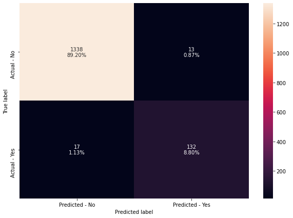

```python
make_confusion_matrix(dTree,y_test_orig)
```

```python
# Recall on train and test
get_recall_score(dTree)
```

```
Recall on training set :  1.0
Recall on test set :  0.8859060402684564
```

```python
feature_names = list(x_test_orig.columns)
print(feature_names)
```

```
['Age', 'Experience', 'Income', 'Family', 'CCAvg', 'Education', 'Mortgage', 'Securities_Account', 'CD_Account', 'Online', 'CreditCard']
```

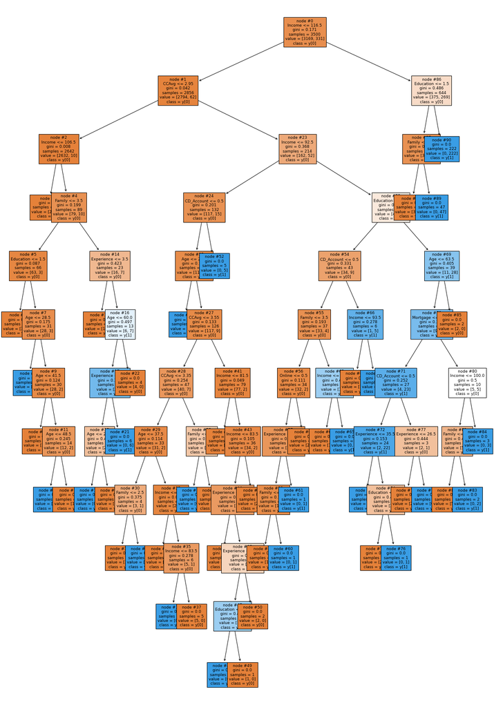

```python
plt.figure(figsize=(20,30))
tree.plot_tree(dTree,feature_names=feature_names,filled=True,fontsize=9,node_ids=True,class_names=True)
plt.show()
```

This tree is very complex. It does have a very strong recall on the test dataset, however it would come at a cost to implement and maintain the model code in the production environment. We should test the effectiveness of a simpler model.

```python
# importance of features in the tree building ( The importance of a feature is computed as the
#(normalized) total reduction of the criterion brought by that feature. It is also known as the Gini importance )

print (pd.DataFrame(dTree.feature_importances_, columns = ["Imp"], index = x_train_orig.columns).sort_values(by = 'Imp', ascending = False))
```

```
                         Imp
Education           0.405914
Income              0.310561
Family              0.167646
CCAvg               0.042183
CD_Account          0.025711
Age                 0.023880
Experience          0.020528
Mortgage            0.003014
Online              0.000561
Securities_Account  0.000000
CreditCard          0.000000
```

[figure not shown]

```python
#get a visual of relative importance of variables
importances = dTree.feature_importances_
indices = np.argsort(importances)

plt.figure(figsize=(20,20))
plt.title('Feature Importances')
plt.barh(range(len(indices)), importances[indices], color='violet', align='center')
plt.yticks(range(len(indices)), [feature_names[i-1] for i in indices])
plt.xlabel('Relative Importance')
plt.show()
```

We will use pre-pruning to tune the model. This reduction in complexity should then be evaluated versus the models' recall.

```python
#try max depth of 4
dTree1 = DecisionTreeClassifier(criterion = 'gini',max_depth=4,random_state=1)
dTree1.fit(x_train_orig, y_train_orig)
```

```
DecisionTreeClassifier(max_depth=4, random_state=1)
```

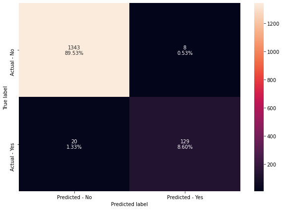

```python
make_confusion_matrix(dTree1, y_test_orig)
```

```python
# Accuracy on train and test
print("Accuracy on training set : ",dTree1.score(x_train_orig, y_train_orig))
print("Accuracy on test set : ",dTree1.score(x_test_orig, y_test_orig))
# Recall on train and test
get_recall_score(dTree1)
```

```
Accuracy on training set :  0.9885714285714285
Accuracy on test set :  0.9813333333333333
Recall on training set :  0.9123867069486404
Recall on test set :  0.8657718120805369
```

The recall here is still very high. Let's try to simplify further with a max depth of 3.

```python
#try max depth of 3
dTree_max3 = DecisionTreeClassifier(criterion = 'gini',max_depth=3,random_state=1)
dTree_max3.fit(x_train_orig, y_train_orig)
```

```
DecisionTreeClassifier(max_depth=3, random_state=1)
```

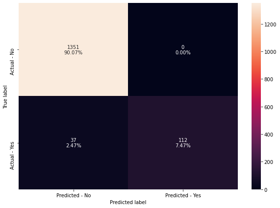

```python
make_confusion_matrix(dTree_max3, y_test_orig)
```

```python
# Accuracy on train and test
print("Accuracy on training set : ",dTree_max3.score(x_train_orig, y_train_orig))
print("Accuracy on test set : ",dTree_max3.score(x_test_orig, y_test_orig))
# Recall on train and test
get_recall_score(dTree_max3)
```

```
Accuracy on training set :  0.9822857142857143
Accuracy on test set :  0.9753333333333334
Recall on training set :  0.8126888217522659
Recall on test set :  0.7516778523489933
```

Compared to the logistic regression, this is still very high recall. It should be discussed with the team who is implmenting the model in the production environment the cost-bnefit-analysis to the additional lift versus the coding complexity and cost to maintain the model of a depth of 3 versus a depth of 4.

From a modeling perspective we would prefer our model to have a nice balance between simplicity and performance, so we will use the model with a depth of 4 and try to persuade the business to use this model if it is cost effective.

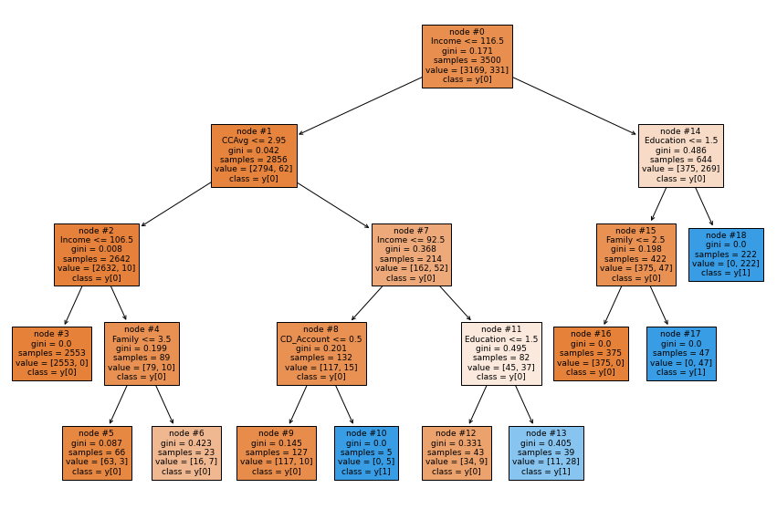

```python
#use the max depth of 4
plt.figure(figsize=(15,10))

tree.plot_tree(dTree1,feature_names=feature_names,filled=True,fontsize=9,node_ids=True,class_names=True)
plt.show()
```

```python
# importance of features in the tree building ( The importance of a feature is computed as the
#(normalized) total reduction of the criterion brought by that feature. It is also known as the Gini importance )

print (pd.DataFrame(dTree1.feature_importances_, columns = ["Imp"], index = x_train_orig.columns).sort_values(by = 'Imp', ascending = False))
```

```
                         Imp
Education           0.448813
Income              0.333366
Family              0.160264
CCAvg               0.042308
CD_Account          0.015249
Age                 0.000000
Experience          0.000000
Mortgage            0.000000
Securities_Account  0.000000
Online              0.000000
CreditCard          0.000000
```

[figure not shown]

```python
importances = dTree1.feature_importances_
indices = np.argsort(importances)

plt.figure(figsize=(10,10))
plt.title('Feature Importances')
plt.barh(range(len(indices)), importances[indices], color='violet', align='center')
plt.yticks(range(len(indices)), [feature_names[i-1] for i in indices])
plt.xlabel('Relative Importance')
plt.show()
```

# optimize decision tree with hyperparameter tuning

```python
from sklearn.model_selection import GridSearchCV
```

```python
# Choose the type of classifier.
estimator = DecisionTreeClassifier(random_state=1)

# Grid of parameters to choose from
## add from article
parameters = {'max_depth': np.arange(1,10),
              'min_samples_leaf': [1, 2, 5, 7, 10,15,20],
              'max_leaf_nodes' : [2, 3, 5, 10],
              'min_impurity_decrease': [0.001,0.01,0.1]
             }

# Type of scoring used to compare parameter combinations
acc_scorer = metrics.make_scorer(metrics.recall_score)

# Run the grid search
grid_obj = GridSearchCV(estimator, parameters, scoring=acc_scorer,cv=5)
grid_obj = grid_obj.fit(x_train_orig, y_train_orig)

# Set the clf to the best combination of parameters
estimator = grid_obj.best_estimator_

# Fit the best algorithm to the data.
estimator.fit(x_train_orig, y_train_orig)
```

```
DecisionTreeClassifier(max_depth=5, max_leaf_nodes=10,
                       min_impurity_decrease=0.001, random_state=1)
```

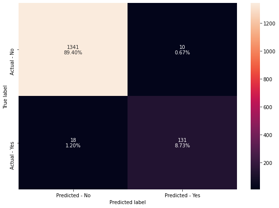

```python
make_confusion_matrix(estimator,y_test_orig)
```

```python
#how does the optimized tree perform?

# Accuracy on train and test
print("Accuracy on training set : ",estimator.score(x_train_orig, y_train_orig))
print("Accuracy on test set : ",estimator.score(x_test_orig, y_test_orig))
# Recall on train and test
get_recall_score(estimator)
```

```
Accuracy on training set :  0.9897142857142858
Accuracy on test set :  0.9813333333333333
Recall on training set :  0.9274924471299094
Recall on test set :  0.8791946308724832
```

The outcome of the models is fairly consistent between the logistic regression and decsion tree. We should rely on the decision tree with the original variables with a max depth of 4. Key variables to target individuals who are likely to take out a personal loan include higher level of education, increased income, increased family size, CC average monthly charges, and having a CD loan. The bank should develop special marketing material for these invididuals and can further classify how to target them based on if they use online accounts or not (can be used to market online or send direct mailers based on their preference for interacting with the bank).

The bank will then be able to measure the success of this marketing campaign to develop future marketing campaigns.